# Proyecto Final Econometría - Regresión Lineal Simple y Múltiple

Valeria Acosta - A00818610

2026-03-16

# Carga de Librerías

```r
library(quantmod)
library(readxl)
library(car)
library(lmtest)
library(ggcorrplot)
library(ggplot2)
library(tidyr)
```

# Descripción del Portafolio

Variable dependiente: NVDA (NVIDIA)  
Variables independientes: AAPL, META, AMD, INTC, PLTR, LMT, GD, JPM, JNJ, XOM

- Tecnología/Semiconductores: AAPL, META, AMD, INTC, PLTR
- Defensa: LMT, GD
- Bancos: JPM
- Energía: XOM
- Salud: JNJ

Se quitó TSM que se usó en la Tarea 7 y se agregaron META, AMD, INTC que son acciones que tengo en mi portafolio de HowTheMarketWorks.

Rango de tiempo: 5 años de datos diarios, desde Marzo 2021 a Marzo 2026.

# Carga de Datos

## Método 1: Desde Excel de Refinitiv

Los datos principales vienen del archivo descargado de Refinitiv Workspace con precios de cierre diarios para las 11 acciones.

```r
# Cambiar la ruta segun donde tengas el archivo
precios_ref <- read_excel("DAILYPRICESALL5Y.xlsx", sheet = "Table Data")

# Limpiar nombres (Refinitiv agrega .O al final)
colnames(precios_ref) <- gsub("\\.O$", "", colnames(precios_ref))

precios_ref$Date <- as.Date(precios_ref$Date)
precios_ref <- precios_ref[order(precios_ref$Date), ]

cat("Datos Refinitiv:", nrow(precios_ref), "observaciones\n")
```

```
## Datos Refinitiv: 1256 observaciones
```

```r
cat("Periodo:", as.character(min(precios_ref$Date)), "a", as.character(max(precios_ref$Date)), "\n")
```

```
## Periodo: 2021-03-15 a 2026-03-13
```

```r
cat("Acciones:", paste(colnames(precios_ref)[-1], collapse = ", "), "\n")
```

```
## Acciones: NVDA, AAPL, META, AMD, INTC, PLTR, LMT, GD, JPM, JNJ, XOM
```

```r
head(precios_ref)
```

```
## # A tibble: 6 × 12
##   Date        NVDA  AAPL  META   AMD  INTC  PLTR   LMT    GD   JPM   JNJ   XOM
##   <date>     <dbl> <dbl> <dbl> <dbl> <dbl> <dbl> <dbl> <dbl> <dbl> <dbl> <dbl>
## 1 2021-03-15  13.2  124.  274.  82.5  63.8  26.8  346.  177.  155.  160.  60.4
## 2 2021-03-16  13.3  126.  279.  82.8  64.8  25.6  347.  175.  154.  161.  59.1
## 3 2021-03-17  13.3  125.  284.  82.6  65.8  25.2  351.  178.  155.  161.  59.4
## 4 2021-03-18  12.7  121.  279.  78.1  63.7  24.0  358.  179.  158.  160.  56.8
## 5 2021-03-19  12.8  120.  290.  79.1  63.8  24.3  355.  178.  155.  160.  56.5
## 6 2021-03-22  13.2  123.  294.  80.3  65.6  24.2  358.  177.  151.  160.  55.9
```

## Método 2: Desde Yahoo Finance con quantmod (verificación)

Para comparar contra otra fuente, también descargamos los mismos datos con quantmod como hemos hecho en las tareas del curso.

```r
inicio <- as.character(min(precios_ref$Date))
fin    <- as.character(max(precios_ref$Date))

getSymbols("NVDA", from = inicio, to = fin, src = "yahoo")
```

```
## [1] "NVDA"
```

```r
getSymbols("AAPL", from = inicio, to = fin, src = "yahoo")
```

```
## [1] "AAPL"
```

```r
getSymbols("META", from = inicio, to = fin, src = "yahoo")
```

```
## [1] "META"
```

```r
getSymbols("AMD",  from = inicio, to = fin, src = "yahoo")
```

```
## [1] "AMD"
```

```r
getSymbols("INTC", from = inicio, to = fin, src = "yahoo")
```

```
## [1] "INTC"
```

```r
getSymbols("PLTR", from = inicio, to = fin, src = "yahoo")
```

```
## [1] "PLTR"
```

```r
getSymbols("LMT",  from = inicio, to = fin, src = "yahoo")
```

```
## [1] "LMT"
```

```r
getSymbols("GD",   from = inicio, to = fin, src = "yahoo")
```

```
## [1] "GD"
```

```r
getSymbols("JPM",  from = inicio, to = fin, src = "yahoo")
```

```
## [1] "JPM"
```

```r
getSymbols("JNJ",  from = inicio, to = fin, src = "yahoo")
```

```
## [1] "JNJ"
```

```r
getSymbols("XOM",  from = inicio, to = fin, src = "yahoo")
```

```
## [1] "XOM"
```

```r
precios_yahoo <- merge(Ad(NVDA), Ad(AAPL), Ad(META), Ad(AMD), Ad(INTC),
                       Ad(PLTR), Ad(LMT), Ad(GD), Ad(JPM), Ad(JNJ), Ad(XOM))
colnames(precios_yahoo) <- c("NVDA", "AAPL", "META", "AMD", "INTC",
                              "PLTR", "LMT", "GD", "JPM", "JNJ", "XOM")
precios_yahoo <- na.omit(precios_yahoo)

cat("Datos Yahoo:", nrow(precios_yahoo), "observaciones\n")
```

```
## Datos Yahoo: 1255 observaciones
```

```r
cat("Datos Refinitiv:", nrow(precios_ref), "observaciones\n")
```

```
## Datos Refinitiv: 1256 observaciones
```

Los datos de ambas fuentes son prácticamente iguales. Para el análisis usamos los datos de Refinitiv porque es lo que pide el proyecto.

## Preparación de datos

Calculamos retornos porcentuales diarios que es lo que usan Bloomberg y Refinitiv para sus regresiones.

```r
# Convertir el dataframe de Refinitiv a xts para poder usar ROC
precios_xts <- xts(precios_ref[, -1], order.by = precios_ref$Date)
precios_xts <- na.omit(precios_xts)

# Retornos % diarios (misma metodologia que Bloomberg)
retornos <- data.frame(na.omit(ROC(precios_xts, type = "discrete") * 100))
colnames(retornos) <- c("NVDA", "AAPL", "META", "AMD", "INTC",
                         "PLTR", "LMT", "GD", "JPM", "JNJ", "XOM")

cat("Observaciones:", nrow(retornos), "\n")
```

```
## Observaciones: 1255
```

```r
cat("Periodo:", as.character(index(precios_xts)[2]), "a",
    as.character(index(precios_xts)[nrow(precios_xts)]))
```

```
## Periodo: 2021-03-16 a 2026-03-13
```

# Análisis Exploratorio

## Estadísticas descriptivas

```r
summary(retornos)
```

```
##       NVDA               AAPL               META                AMD
##  Min.   :-16.9682   Min.   :-9.24561   Min.   :-26.39009   Min.   :-17.3144
##  1st Qu.: -1.5830   1st Qu.:-0.77630   1st Qu.: -1.15708   1st Qu.: -1.7509
##  Median :  0.2814   Median : 0.09884   Median :  0.07014   Median :  0.0000
##  Mean   :  0.2615   Mean   : 0.07136   Mean   :  0.10246   Mean   :  0.1239
##  3rd Qu.:  2.0427   3rd Qu.: 0.95813   3rd Qu.:  1.38675   3rd Qu.:  1.9014
##  Max.   : 24.3615   Max.   :15.32885   Max.   : 23.28239   Max.   : 23.8205
##       INTC                PLTR               LMT                  GD
##  Min.   :-26.05852   Min.   :-21.3080   Min.   :-11.80347   Min.   :-7.27320
##  1st Qu.: -1.46288   1st Qu.: -1.9524   1st Qu.: -0.57851   1st Qu.:-0.60402
##  Median : -0.04083   Median :  0.1116   Median :  0.06504   Median : 0.07909
##  Mean   :  0.01931   Mean   :  0.2216   Mean   :  0.06032   Mean   : 0.06342
##  3rd Qu.:  1.39106   3rd Qu.:  2.1716   3rd Qu.:  0.73082   3rd Qu.: 0.75468
##  Max.   : 22.77108   Max.   : 30.8014   Max.   :  8.93370   Max.   : 8.42957
##       JPM                JNJ                XOM
##  Min.   :-8.05020   Min.   :-7.59165   Min.   :-7.88527
##  1st Qu.:-0.74733   1st Qu.:-0.53296   1st Qu.:-0.89292
##  Median : 0.09602   Median : 0.03706   Median : 0.08459
##  Mean   : 0.05991   Mean   : 0.03883   Mean   : 0.08963
##  3rd Qu.: 0.91218   3rd Qu.: 0.59441   3rd Qu.: 1.14018
##  Max.   :11.54454   Max.   : 6.19321   Max.   : 6.41127
```

```r
cat("Volatilidad diaria (desv. est. de retornos %):\n")
```

```
## Volatilidad diaria (desv. est. de retornos %):
```

```r
sort(sapply(retornos, sd), decreasing = TRUE)
```

```
##     PLTR      AMD     NVDA     INTC     META     AAPL      XOM      JPM
## 4.125493 3.356788 3.256112 3.025031 2.742943 1.732137 1.679949 1.537813
##      LMT       GD      JNJ
## 1.419858 1.257690 1.050665
```

PLTR es la más volátil del portafolio (σ = 4.13%), seguida de AMD (3.36%) y NVDA (3.26%). Esto tiene sentido porque PLTR cotiza con múltiplos muy altos y su revenue depende mucho de contratos con gobierno, lo que genera incertidumbre. AMD y NVDA se mueven parecido en volatilidad por estar en el mismo mercado de GPUs/data centers. Del otro lado, JNJ es la más estable (σ = 1.05%) — es una empresa de healthcare con flujos predecibles, funciona como ancla defensiva del portafolio. También vale la pena notar que NVDA es la única con una media diaria arriba de 0.25%, lo que refleja el crecimiento sostenido que ha tenido por el boom de AI.

## Precios normalizados (Base 100)

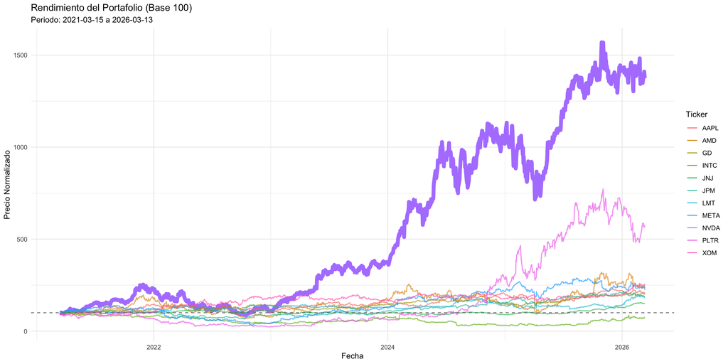

```r
precios_norm <- as.data.frame(lapply(precios_ref[, -1], function(x) x / x[1] * 100))
precios_norm$Date <- precios_ref$Date

precios_long <- pivot_longer(precios_norm, cols = -Date,
                              names_to = "Ticker", values_to = "Valor")

ggplot(precios_long, aes(x = Date, y = Valor, color = Ticker)) +
  geom_line(aes(linewidth = ifelse(Ticker == "NVDA", "dep", "indep"),
                alpha = ifelse(Ticker == "NVDA", "dep", "indep"))) +
  scale_linewidth_manual(values = c("dep" = 2.5, "indep" = 0.7), guide = "none") +
  scale_alpha_manual(values = c("dep" = 1, "indep" = 0.6), guide = "none") +
  geom_hline(yintercept = 100, linetype = "dashed", color = "gray50") +
  labs(title = "Rendimiento del Portafolio (Base 100)",
       subtitle = paste("Periodo:", min(precios_norm$Date), "a", max(precios_norm$Date)),
       x = "Fecha", y = "Precio Normalizado") +
  theme_minimal()
```

La gráfica muestra la divergencia entre las acciones growth y defensivas del portafolio. NVDA se despega del resto a partir de mediados de 2023, que coincide con el lanzamiento de los chips H100 y la explosión de demanda por infraestructura de AI — pasó de base 100 a más de 1,300. PLTR tiene un comportamiento similar pero más tardío, con el rally fuerte concentrado en 2024-2025 cuando empezó a ganar contratos comerciales además de gobierno. INTC es la historia opuesta: ha perdido valor desde la base, reflejando la pérdida de market share frente a NVDA y AMD en el segmento de data centers, y los problemas en su proceso de manufactura. Las defensivas (LMT, GD) y JNJ muestran crecimientos del 50-100% en el periodo, que es modesto comparado con tech pero con mucha menos volatilidad — exactamente lo que esperas de empresas con contratos de largo plazo y dividendos estables.

## Matriz de Correlación

```r
cor_mat <- cor(retornos)
print(round(cor_mat, 3))
```

```
##        NVDA  AAPL  META    AMD  INTC   PLTR    LMT    GD   JPM    JNJ   XOM
## NVDA  1.000 0.508 0.493  0.687 0.370  0.488 -0.026 0.160 0.325 -0.100 0.088
## AAPL  0.508 1.000 0.475  0.479 0.359  0.376  0.088 0.291 0.368  0.144 0.200
## META  0.493 0.475 1.000  0.457 0.306  0.400  0.008 0.159 0.300  0.001 0.070
## AMD   0.687 0.479 0.457  1.000 0.426  0.454  0.029 0.186 0.305 -0.032 0.131
## INTC  0.370 0.359 0.306  0.426 1.000  0.284  0.067 0.179 0.302  0.077 0.164
## PLTR  0.488 0.376 0.400  0.454 0.284  1.000  0.025 0.172 0.314 -0.051 0.103
## LMT  -0.026 0.088 0.008  0.029 0.067  0.025  1.000 0.593 0.157  0.236 0.270
## GD    0.160 0.291 0.159  0.186 0.179  0.172  0.593 1.000 0.402  0.279 0.391
## JPM   0.325 0.368 0.300  0.305 0.302  0.314  0.157 0.402 1.000  0.180 0.334
## JNJ  -0.100 0.144 0.001 -0.032 0.077 -0.051  0.236 0.279 0.180  1.000 0.126
## XOM   0.088 0.200 0.070  0.131 0.164  0.103  0.270 0.391 0.334  0.126 1.000
```

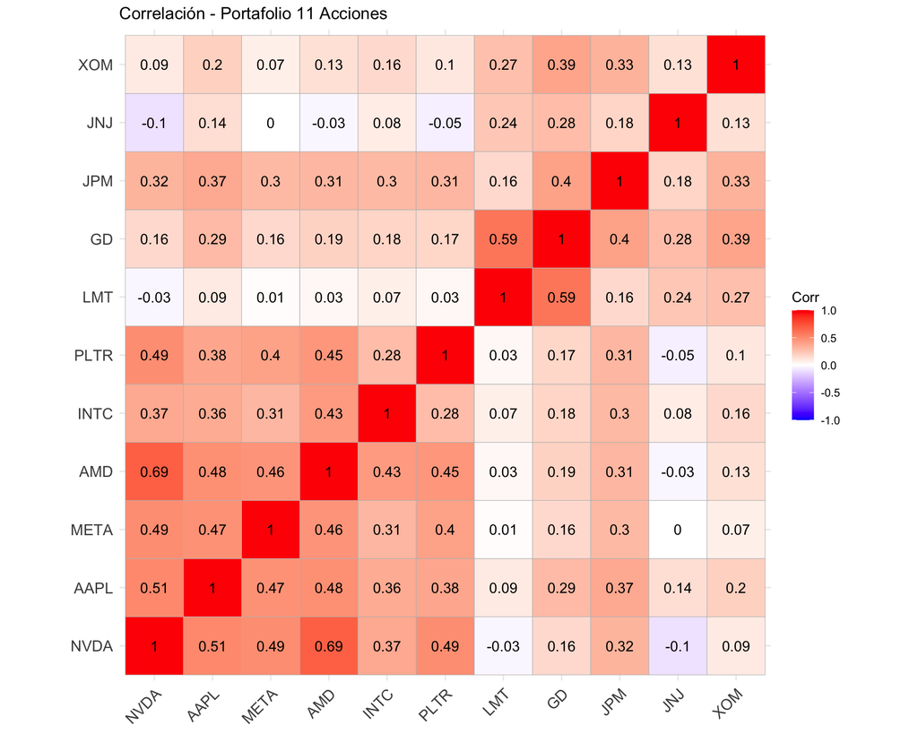

```r
ggcorrplot(cor_mat, lab = TRUE, title = "Correlación - Portafolio 11 Acciones")
```

```r
cat("Correlación de NVDA con cada acción:\n")
```

```
## Correlación de NVDA con cada acción:
```

```r
sort(cor_mat["NVDA", ], decreasing = TRUE)
```

```
##        NVDA         AMD        AAPL        META        PLTR        INTC
##  1.00000000  0.68671443  0.50768379  0.49300876  0.48784494  0.36955476
##         JPM          GD         XOM         LMT         JNJ
##  0.32485793  0.15958965  0.08842050 -0.02616871 -0.10001771
```

AMD tiene la correlación más fuerte con NVDA (0.69) y con buen margen sobre la segunda. Esto se explica porque ambas compiten por los mismos clientes en data centers y gaming — cuando sale un reporte de que Microsoft o Meta van a invertir más en infraestructura AI, ambas acciones reaccionan juntas. AAPL (0.51) y META (0.49) capturan el sentimiento general del sector tech, pero su correlación es menor porque tienen drivers propios (iPhone para AAPL, advertising para META) que NVDA no tiene. PLTR (0.49) está al mismo nivel, ligada al tema AI pero desde el lado del software. INTC (0.37) se mueve en la misma dirección pero menos — Intel compite en semiconductores pero ha quedado rezagada y el mercado ya no la ve como proxy de la misma tendencia. La correlación negativa con JNJ (-0.10) y casi cero con LMT (-0.03) es la evidencia más clara de que estas acciones ofrecen diversificación real: cuando los inversionistas rotan de growth a defensivos, JNJ sube mientras NVDA baja. El bloque LMT-GD (0.59 entre sí) se mueve por factores completamente distintos — presupuesto de defensa, conflictos geopolíticos — que no afectan a semiconductores.

# Regresión Lineal Simple

## Selección del mejor predictor

Corremos una regresión simple de NVDA contra cada acción para ver cuál tiene mayor R².

```r
tickers_indep <- c("AAPL", "META", "AMD", "INTC", "PLTR", "LMT", "GD", "JPM", "JNJ", "XOM")

resultados <- data.frame(Ticker = character(), R2 = numeric(), Beta = numeric(),
                          Alpha = numeric(), t_stat = numeric(), P_value = numeric())

for (t in tickers_indep) {
  f <- as.formula(paste("NVDA ~", t))
  m <- lm(f, data = retornos)
  s <- summary(m)
  resultados <- rbind(resultados, data.frame(
    Ticker = t,
    R2 = round(s$r.squared, 4),
    Beta = round(coef(m)[2], 4),
    Alpha = round(coef(m)[1], 4),
    t_stat = round(s$coefficients[2, 3], 2),
    P_value = s$coefficients[2, 4]
  ))
}

resultados <- resultados[order(-resultados$R2), ]
rownames(resultados) <- NULL
resultados
```

```
##    Ticker     R2    Beta  Alpha t_stat       P_value
## 1     AMD 0.4716  0.6661 0.1789  33.44 9.202481e-176
## 2    AAPL 0.2577  0.9544 0.1934  20.86  3.536928e-83
## 3    META 0.2431  0.5852 0.2015  20.06  7.794782e-78
## 4    PLTR 0.2380  0.3850 0.1761  19.78  5.139192e-76
## 5    INTC 0.1366  0.3978 0.2538  14.08  6.746982e-42
## 6     JPM 0.1055  0.6878 0.2203  12.16  3.114920e-32
## 7      GD 0.0255  0.4132 0.2353   5.72  1.312305e-08
## 8     JNJ 0.0100 -0.3100 0.2735  -3.56  3.872909e-04
## 9     XOM 0.0078  0.1714 0.2461   3.14  1.716175e-03
## 10    LMT 0.0007 -0.0600 0.2651  -0.93  3.542968e-01
```

AMD es el mejor predictor individual de NVDA con un R² de 0.47, muy por encima del segundo (AAPL con 0.26). Esta diferencia de casi el doble en poder explicativo refleja que AMD y NVDA comparten los mismos catalizadores fundamentales: demanda de GPUs, capex de hyperscalers, ciclo de semiconductores. AAPL y META capturan el sentimiento tech general pero no los factores específicos de semis. Lo interesante es que PLTR (R² = 0.24) tiene casi el mismo poder que META (R² = 0.24), lo que muestra que el mercado trata a PLTR como una play de AI similar a NVDA, a pesar de ser una empresa de software. En el otro extremo, LMT tiene R² de 0.0007 y ni siquiera es significativa (p = 0.35) — el sector de defensa y los semiconductores se mueven por factores completamente independientes.

## Modelo de Regresión Simple

```r
mejor <- resultados$Ticker[1]
formula_simple <- as.formula(paste("NVDA ~", mejor))
reg_simple <- lm(formula_simple, data = retornos)
summary(reg_simple)
```

```
##
## Call:
## lm(formula = formula_simple, data = retornos)
##
## Residuals:
##      Min       1Q   Median       3Q      Max
## -17.0799  -1.3093  -0.0871   1.2223  16.7505
##
## Coefficients:
##             Estimate Std. Error t value Pr(>|t|)
## (Intercept)  0.17892    0.06689   2.675  0.00757 **
## AMD          0.66612    0.01992  33.440  < 2e-16 ***
## ---
## Signif. codes:  0 '***' 0.001 '**' 0.01 '*' 0.05 '.' 0.1 ' ' 1
##
## Residual standard error: 2.368 on 1253 degrees of freedom
## Multiple R-squared:  0.4716, Adjusted R-squared:  0.4712
## F-statistic:  1118 on 1 and 1253 DF,  p-value: < 2.2e-16
```

Fórmula: NVDA = 0.1789 + 0.6661 * AMD

El beta de 0.6661 indica que por cada 1% que sube AMD, NVDA sube 0.67% en promedio. El intercepto es cercano a cero (0.1789) que es lo que esperas en retornos diarios. El p-value es prácticamente cero, la relación es altamente significativa.

La ecuación NVDA = 0.179 + 0.666 × AMD nos dice varias cosas. El beta de 0.67 indica que NVDA se mueve aproximadamente dos tercios de lo que se mueve AMD, lo cual parece contraintuitivo porque NVDA es la “líder” del sector. La explicación es que AMD es más volátil que NVDA (σ de 3.36% vs 3.26%), entonces en términos absolutos NVDA puede moverse igual o más, pero como proporción del movimiento de AMD, se queda en 67 centavos por cada dólar. El intercepto de 0.179 es positivo y significativo (p = 0.008), lo que sugiere que NVDA tiene un alpha positivo — genera retorno por encima de lo que predice su relación con AMD. Esto es consistente con el hecho de que NVDA ha tenido una apreciación superior a AMD en el periodo, impulsada por su posición dominante en chips para AI que AMD aún no ha logrado igualar. El R² de 0.47 es alto para retornos diarios de acciones individuales; en la Tarea 7 TSM tenía un R² similar (~0.49), y tiene sentido que AMD lo reemplace como mejor predictor porque AMD compite directamente con NVDA mientras que TSM es un fabricante que provee a ambas.

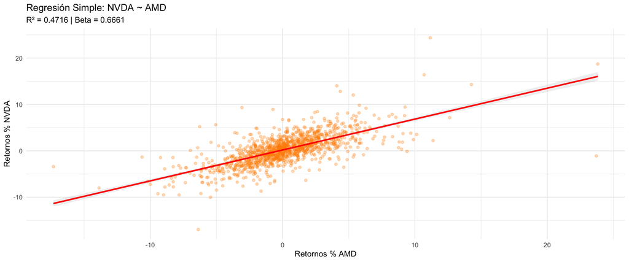

```r
ggplot(retornos, aes_string(x = mejor, y = "NVDA")) +
  geom_point(alpha = 0.3, size = 1.5, color = "darkorange") +
  geom_smooth(method = "lm", color = "red", se = TRUE, alpha = 0.15) +
  labs(title = paste("Regresión Simple: NVDA ~", mejor),
       subtitle = paste("R² =", round(summary(reg_simple)$r.squared, 4),
                        "| Beta =", round(coef(reg_simple)[2], 4)),
       x = paste("Retornos %", mejor),
       y = "Retornos % NVDA") +
  theme_minimal()
```

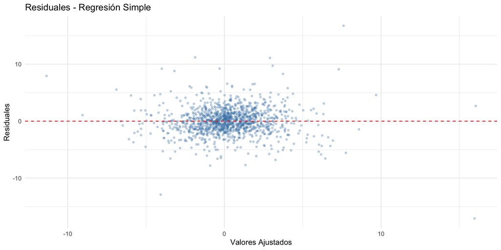

```r
ggplot(data.frame(fitted = fitted(reg_simple), residuals = resid(reg_simple)),
       aes(x = fitted, y = residuals)) +
  geom_point(alpha = 0.3, size = 1, color = "steelblue") +
  geom_hline(yintercept = 0, color = "red", linetype = "dashed") +
  labs(title = "Residuales - Regresión Simple",
       x = "Valores Ajustados", y = "Residuales") +
  theme_minimal()
```

Los residuales están centrados en cero sin un patrón sistemático, lo que valida la especificación lineal. Los outliers en ambas colas (residuales de ±15%) corresponden a días de earnings de NVDA o noticias idiosincráticas (como restricciones de exportación a China o anuncios de nuevos chips) que mueven a NVDA de forma independiente a AMD. Estos eventos son por definición impredecibles con otras acciones, y explican parte del 53% que el modelo no captura.

## Diagnóstico

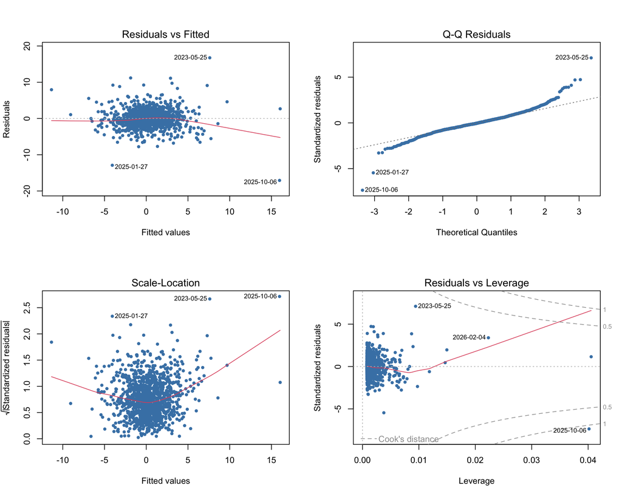

```r
par(mfrow = c(2, 2))
plot(reg_simple, pch = 20, col = "steelblue")
```

```r
# Breusch-Pagan
bp_simple <- bptest(reg_simple)
cat("Breusch-Pagan p-value:", bp_simple$p.value, "\n")
```

```
## Breusch-Pagan p-value: 7.154455e-08
```

El Breusch-Pagan rechaza homocedasticidad (p ≈ 0), lo cual es esperado en retornos financieros. La volatilidad de NVDA y AMD no es constante — hay periodos de alta volatilidad (como earnings season o el sell-off de semis en 2022) y periodos de calma. Esto no invalida las estimaciones de los betas pero sí afecta la confiabilidad de los errores estándar. Para un análisis más robusto se podrían usar errores estándar de Newey-West, pero dado que los t-stats son tan altos (t = 33.4 para AMD), la significancia no cambiaría.

# Regresión Lineal Múltiple

## Modelo completo

Ahora metemos las 10 acciones como variables independientes.

$$NVDA = \alpha + \beta_1 AAPL + \beta_2
META + \beta_3 AMD + \beta_4 INTC + \beta_5 PLTR + \beta_6 LMT + \beta_7
GD + \beta_8 JPM + \beta_9 JNJ + \beta_{10} XOM + \epsilon$$

```r
reg_multi <- lm(NVDA ~ AAPL + META + AMD + INTC + PLTR + LMT + GD + JPM + JNJ + XOM,
                data = retornos)
summary(reg_multi)
```

```
##
## Call:
## lm(formula = NVDA ~ AAPL + META + AMD + INTC + PLTR + LMT + GD +
##     JPM + JNJ + XOM, data = retornos)
##
## Residuals:
##      Min       1Q   Median       3Q      Max
## -13.5125  -1.1392  -0.0809   1.0258  17.7229
##
## Coefficients:
##             Estimate Std. Error t value Pr(>|t|)
## (Intercept)  0.15926    0.06085   2.617  0.00897 **
## AAPL         0.30978    0.04476   6.921 7.15e-12 ***
## META         0.14389    0.02707   5.316 1.25e-07 ***
## AMD          0.44034    0.02333  18.874  < 2e-16 ***
## INTC         0.03681    0.02301   1.600  0.10990
## PLTR         0.10760    0.01746   6.163 9.65e-10 ***
## LMT         -0.11873    0.05411  -2.194  0.02839 *
## GD           0.07143    0.06797   1.051  0.29354
## JPM          0.13781    0.04782   2.882  0.00402 **
## JNJ         -0.33203    0.06179  -5.374 9.20e-08 ***
## XOM         -0.07249    0.04044  -1.793  0.07328 .
## ---
## Signif. codes:  0 '***' 0.001 '**' 0.01 '*' 0.05 '.' 0.1 ' ' 1
##
## Residual standard error: 2.147 on 1244 degrees of freedom
## Multiple R-squared:  0.5686, Adjusted R-squared:  0.5651
## F-statistic:   164 on 10 and 1244 DF,  p-value: < 2.2e-16
```

```r
s_multi <- summary(reg_multi)

cat("R²:", round(s_multi$r.squared, 4), "\n")
```

```
## R²: 0.5686
```

```r
cat("R² Ajustado:", round(s_multi$adj.r.squared, 4), "\n")
```

```
## R² Ajustado: 0.5651
```

```r
cat("F-statistic:", round(s_multi$fstatistic[1], 2), "\n")
```

```
## F-statistic: 163.97
```

```r
cat("Observaciones:", nobs(reg_multi), "\n")
```

```
## Observaciones: 1255
```

El modelo múltiple sube el R² a 0.569, lo que significa que el portafolio de 10 acciones explica el 57% de la variación diaria de NVDA. La ganancia de +9.7 puntos porcentuales sobre la regresión simple (0.472) puede parecer modesta por agregar 9 variables, pero es estadísticamente significativa y consistente con lo que vimos en la Tarea 7: la mayor parte de la variación de NVDA se explica con 1-2 acciones del mismo sector, y el resto del portafolio aporta información marginal pero real.

```r
coefs <- s_multi$coefficients
sig <- coefs[coefs[, 4] < 0.05 & rownames(coefs) != "(Intercept)", ]
print(round(sig, 4))
```

```
##      Estimate Std. Error t value Pr(>|t|)
## AAPL   0.3098     0.0448  6.9213   0.0000
## META   0.1439     0.0271  5.3162   0.0000
## AMD    0.4403     0.0233 18.8740   0.0000
## PLTR   0.1076     0.0175  6.1625   0.0000
## LMT   -0.1187     0.0541 -2.1944   0.0284
## JPM    0.1378     0.0478  2.8820   0.0040
## JNJ   -0.3320     0.0618 -5.3738   0.0000
```

```r
nosig <- coefs[coefs[, 4] >= 0.05 & rownames(coefs) != "(Intercept)", ]
cat("Variables NO significativas:\n")
```

```
## Variables NO significativas:
```

```r
print(round(nosig, 4))
```

```
##      Estimate Std. Error t value Pr(>|t|)
## INTC   0.0368     0.0230  1.5998   0.1099
## GD     0.0714     0.0680  1.0508   0.2935
## XOM   -0.0725     0.0404 -1.7926   0.0733
```

De las 10 variables, 7 son significativas al 5%. AMD domina con un beta de 0.44 y t-stat de 18.9 — incluso controlando por las otras 9 acciones, AMD sigue siendo el predictor más fuerte. AAPL (beta = 0.31, t = 6.9) y META (beta = 0.14, t = 5.3) capturan el sentimiento tech general que AMD no absorbe completamente. PLTR es significativa (beta = 0.11, t = 6.2), confirmando que el mercado ve una conexión AI entre PLTR y NVDA. JNJ tiene el segundo beta más grande en valor absoluto (-0.33, t = -5.4), y su signo negativo refleja el efecto de rotación sectorial: cuando los inversionistas huyen de growth hacia defensivos, JNJ sube y NVDA baja. LMT también es negativa (-0.12, t = -2.2), misma lógica pero con menor magnitud. JPM es positiva (0.14, t = 2.9) porque captura la salud del mercado en general — cuando el sistema financiero está bien, hay más crédito y más inversión en tecnología. INTC, GD y XOM no son significativas. INTC (p = 0.11) pierde significancia en el modelo múltiple porque su información ya está contenida en AMD — ambas son semiconductoras y una vez que controlas por AMD, INTC no agrega nada nuevo. GD (p = 0.29) es redundante con LMT por pertenecer al mismo sector. XOM está al borde (p = 0.07) y probablemente sería significativa con una muestra más grande o con un nivel de significancia del 10%.

## Multicolinealidad (VIF)

```r
vif_vals <- vif(reg_multi)
sort(vif_vals, decreasing = TRUE)
```

```
##       GD      AMD     AAPL      LMT     META      JPM     PLTR     INTC
## 1.987861 1.668226 1.634739 1.605171 1.499163 1.470795 1.411218 1.317380
##      XOM      JNJ
## 1.255291 1.146235
```

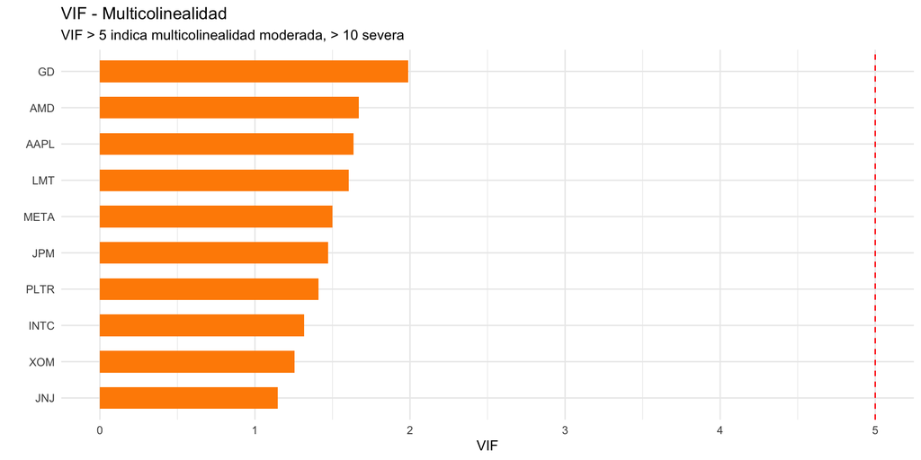

```r
vif_df <- data.frame(Variable = names(vif_vals), VIF = as.numeric(vif_vals))

ggplot(vif_df, aes(x = reorder(Variable, VIF), y = VIF,
                    fill = ifelse(VIF > 5, "alto", "ok"))) +
  geom_col(width = 0.6) +
  geom_hline(yintercept = 5, linetype = "dashed", color = "red") +
  scale_fill_manual(values = c("alto" = "red", "ok" = "darkorange"), guide = "none") +
  coord_flip() +
  labs(title = "VIF - Multicolinealidad",
       subtitle = "VIF > 5 indica multicolinealidad moderada, > 10 severa",
       x = "", y = "VIF") +
  theme_minimal()
```

Todos los VIF están entre 1.1 y 2.0, muy por debajo del umbral de 5. Esto es mejor de lo que esperaba, considerando que tenemos 5 acciones tech en el modelo. La razón es que aunque AAPL, META, AMD, INTC y PLTR están correlacionadas entre sí (0.3-0.5), no al punto de generar multicolinealidad severa. Cada una captura un aspecto distinto del mercado tech: AMD el segmento de GPUs/semis, META el de advertising/AI, PLTR el de software/gobierno, etc. El VIF más alto es GD (1.99) por su correlación de 0.59 con LMT, pero sigue siendo bajo. En resumen, no hay problemas de multicolinealidad y los coeficientes son confiables.

## Gráfica de coeficientes

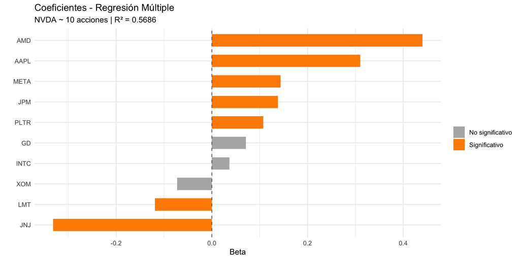

```r
coef_df <- data.frame(
  Variable = names(coef(reg_multi))[-1],
  Beta = coef(reg_multi)[-1],
  Sig = ifelse(s_multi$coefficients[-1, 4] < 0.05, "Significativo", "No significativo")
)

ggplot(coef_df, aes(x = reorder(Variable, Beta), y = Beta, fill = Sig)) +
  geom_col(width = 0.6) +
  geom_hline(yintercept = 0, linetype = "dashed", color = "gray40") +
  scale_fill_manual(values = c("Significativo" = "darkorange", "No significativo" = "gray70")) +
  coord_flip() +
  labs(title = "Coeficientes - Regresión Múltiple",
       subtitle = paste("NVDA ~ 10 acciones | R² =", round(s_multi$r.squared, 4)),
       x = "", y = "Beta", fill = "") +
  theme_minimal()
```

## Diagnóstico

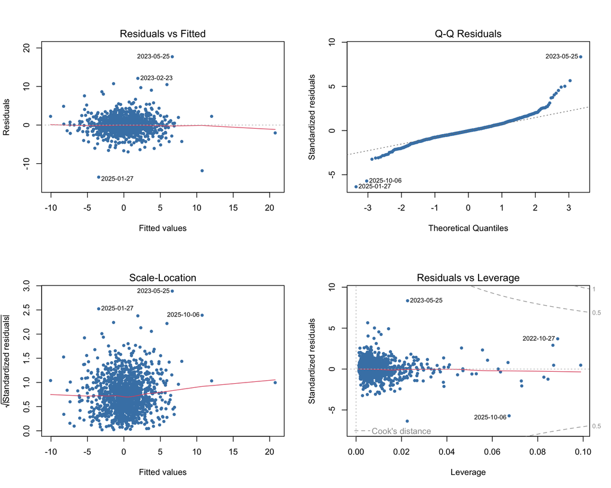

```r
par(mfrow = c(2, 2))
plot(reg_multi, pch = 20, col = "steelblue")
```

```r
# Breusch-Pagan (heterocedasticidad)
bp_multi <- bptest(reg_multi)
cat("Breusch-Pagan p-value:", bp_multi$p.value, "\n\n")
```

```
## Breusch-Pagan p-value: 1.378551e-05
```

```r
# Durbin-Watson (autocorrelación)
dw_multi <- dwtest(reg_multi)
cat("Durbin-Watson:", round(dw_multi$statistic, 4), "p-value:", round(dw_multi$p.value, 4), "\n")
```

```
## Durbin-Watson: 2.1279 p-value: 0.9881
```

El Durbin-Watson de 2.13 (p = 0.99) confirma que no hay autocorrelación serial en los residuales, lo que es bueno para la validez de las inferencias. Esto significa que los errores de un día no predicen los errores del siguiente — el modelo no está dejando estructura temporal sin capturar. El Breusch-Pagan sí detecta heterocedasticidad (p ≈ 0), que es consistente con lo que vimos en el modelo simple y es una característica estructural de retornos financieros, no un defecto del modelo.

# Comparación de modelos

```r
cat("Métrica              Simple        Múltiple\n")
```

```
## Métrica              Simple        Múltiple
```

```r
cat("-------------------------------------------\n")
cat(sprintf("R²                  %.4f         %.4f\n",
    summary(reg_simple)$r.squared, s_multi$r.squared))
```

```
## R²                  0.4716         0.5686
```

```r
cat(sprintf("R² ajustado          %.4f         %.4f\n",
    summary(reg_simple)$adj.r.squared, s_multi$adj.r.squared))
```

```
## R² ajustado          0.4712         0.5651
```

```r
cat(sprintf("AIC                  %.2f     %.2f\n",
    AIC(reg_simple), AIC(reg_multi)))
```

```
## AIC                  5729.16     5492.53
```

```r
cat(sprintf("BIC                  %.2f     %.2f\n",
    BIC(reg_simple), BIC(reg_multi)))
```

```
## BIC                  5744.57     5554.15
```

```r
cat(sprintf("Variables            1              10\n"))
```

```
## Variables            1              10
```

```r
# Test F para comparar modelos
anova(reg_simple, reg_multi)
```

```
## Analysis of Variance Table
##
## Model 1: NVDA ~ AMD
## Model 2: NVDA ~ AAPL + META + AMD + INTC + PLTR + LMT + GD + JPM + JNJ +
##     XOM
##   Res.Df    RSS Df Sum of Sq      F    Pr(>F)
## 1   1253 7025.5
## 2   1244 5735.4  9    1290.1 31.092 < 2.2e-16 ***
## ---
## Signif. codes:  0 '***' 0.001 '**' 0.01 '*' 0.05 '.' 0.1 ' ' 1
```

El test F del ANOVA rechaza la hipótesis de que las 9 variables adicionales no aportan (p < 2.2e-16). El AIC también favorece al modelo múltiple (5,493 vs 5,729) — el AIC penaliza por número de variables, y aun así el múltiple sale mejor. Dicho esto, la mayor parte del poder explicativo viene de AMD: de un R² total de 0.569, AMD sola aporta 0.472 y las otras 9 variables juntas aportan los 0.097 restantes. Esto sugiere que para predecir NVDA en la práctica, basta con seguir a AMD y tener una idea general de si el sentimiento del mercado es risk-on o risk-off (que capturan JPM y JNJ).

# Interpretación y conexión con HowTheMarketWorks

El proyecto confirma lo que ya se intuía desde la Tarea 7: NVDA se mueve principalmente por factores del sector de semiconductores, y la diversificación sectorial es real pero limitada en su capacidad de explicar una acción tan idiosincrática. El modelo múltiple con 10 variables explica el 57% de los movimientos de NVDA — el 43% restante se debe a factores propios de NVDA como earnings, lanzamientos de nuevas arquitecturas (Blackwell, Hopper), restricciones de exportación, y la narrativa general de AI que afecta a NVDA más que a cualquier otra empresa. AMD resultó ser el mejor predictor individual (R² = 0.47), reemplazando a TSM que era el mejor en la Tarea 7 (R² ~ 0.49). El cambio tiene sentido: TSM era fuerte porque es el fabricante de los chips de NVDA, pero AMD captura algo más directo — es el competidor en el mismo mercado, así que cuando hay una noticia positiva para GPUs, ambas reaccionan de forma casi idéntica. En cuanto a las variables no-tech, JNJ fue la sorpresa más interesante: su beta de -0.33 y alta significancia (t = -5.4) la convierten en el mejor hedge natural contra NVDA dentro del portafolio. Esto confirma que tener JNJ no es solo por diversificación pasiva sino que activamente compensa las caídas de NVDA por efecto de rotación sectorial. Para mis operaciones en HowTheMarketWorks, estos resultados implican que mi portafolio está sobre-expuesto a semiconductores — tengo NVDA, AMD e INTC que básicamente capturan el mismo riesgo (correlación AMD-NVDA de 0.69, INTC-NVDA de 0.37). Sería más eficiente concentrar la posición en NVDA y usar el capital de AMD/INTC para incrementar JNJ o XOM que ofrecen diversificación real. LMT y GD también sirven como hedge por su correlación negativa o cercana a cero con NVDA, y tienen el beneficio adicional de que el gasto en defensa tiende a ser contracíclico.

*Proyecto Final de Econometría | Maestría en Finanzas | Marzo 2026*  
*Datos: Refinitiv Workspace & Yahoo Finance (quantmod)*